# Product Data Analyst - Test Assignment 1

Analysis on Book-Crossing dataset

Toomas Eilat

21.04.2018

# Overview and setup

For this assignment I am using data from [Book-Crossing dataset](http://www2.informatik.uni-freiburg.de/~cziegler/BX/). I had some encoding problems with importing SQL Dump file into a local MySQL database. Therefor I used the CSV Dump and write the BX-Book-Ratings table into a local SQLite database to demonstrate my SQL query writing skills. In parallel I also did the analysis in R.

### Load and write the data into a database

```r
# load packages
library(RSQLite)
library(tidyverse)
library(DBI)
library(janitor)
library(skimr)
library(ggforce)
library(hrbrthemes)
library(patchwork)
library(knitr)
library(kableExtra)

# load data from csv file
bx_book_ratings <- read_csv2("data/BX-Book-Ratings.csv") %>%
  clean_names()  # modify column names

# create a local SQLite databas
con <- dbConnect(RSQLite::SQLite(), "data/book_crossing.sqlite")

# write table into database
dbWriteTable(con, "bx_book_ratings", bx_book_ratings, overwrite = TRUE)
```

# Analysis

From the following analysis I exclude implicit ratings expressed by 0. As the 0 ratings account for 62% of all the ratings in the database, they would skew the results.

## 1. Users with exactly 2 ratings

How many users have made exactly 2 ratings?

### SQL query

```sql
select
count(distinct bx_book_ratings.user_id) as no_of_users_with_2_ratings
from bx_book_ratings
inner join (
  select user_id
  from bx_book_ratings
  where book_rating > 0
  group by user_id
  having count(*) = 2
) as rating_2 on bx_book_ratings.user_id = rating_2.user_id
```

### R

```r
r_users_with_2_ratings <- bx_book_ratings %>%
  filter(book_rating > 0) %>%
  count(user_id) %>%
  filter(n == 2) %>%
  summarise(n = n()) %>%
  pull(n)
```

### Result

There are **9855** users with exactly 2 ratings in the dataset.

## 2. Mean, median, mode, and range for number of ratings

Find the mean, median, mode, and range for number of ratings made for book.

### SQL query

With the first query I calculated the mean, median and range (max and min) for number of ratings given to each book.

```sql
with isbn_rating as (
  select isbn,
  count(*) as n
  from bx_book_ratings
  where book_rating > 0
  group by isbn
)

select
avg(n) as mean,
median(n) as median,
max(n) as max,
min(n) as min
from isbn_rating
```

As there is no native function in SQLite to calculate mode I used a custom subquery to calculate the mode.

```sql
with isbn_rating as (
  select isbn,
  count(*) as n
  from bx_book_ratings
  where book_rating > 0
  group by isbn
)

select
n as mode
from isbn_rating
group by n
having count(*) = (
  select
  count(*) as count
  from isbn_rating
  group by n
  order by count desc
  limit 1
)
```

### R

```r
# custom function to calculate mode
# from https://www.tutorialspoint.com/r/r_mean_median_mode.htm
getmode <- function(v) {
   uniqv <- unique(v)
   uniqv[which.max(tabulate(match(v, uniqv)))]
}

# calculate summary statistics
r_number_of_ratings_summary <- bx_book_ratings %>%
  filter(book_rating > 0) %>%
  count(isbn) %>%
  summarise(mean = round(mean(n), 1),
            median = median(n),
            mode = getmode(n),
            min = min(n),
            max = max(n))
```

### Result

Mean, median, mode, and range for number of ratings is presented in the table and chart below.

```r
r_number_of_ratings_summary %>%
  kable("html") %>%
  kable_styling()
```

| mean | median | mode | min | max |
| --- | --- | --- | --- | --- |
| 2.3 | 1 | 1 | 1 | 707 |

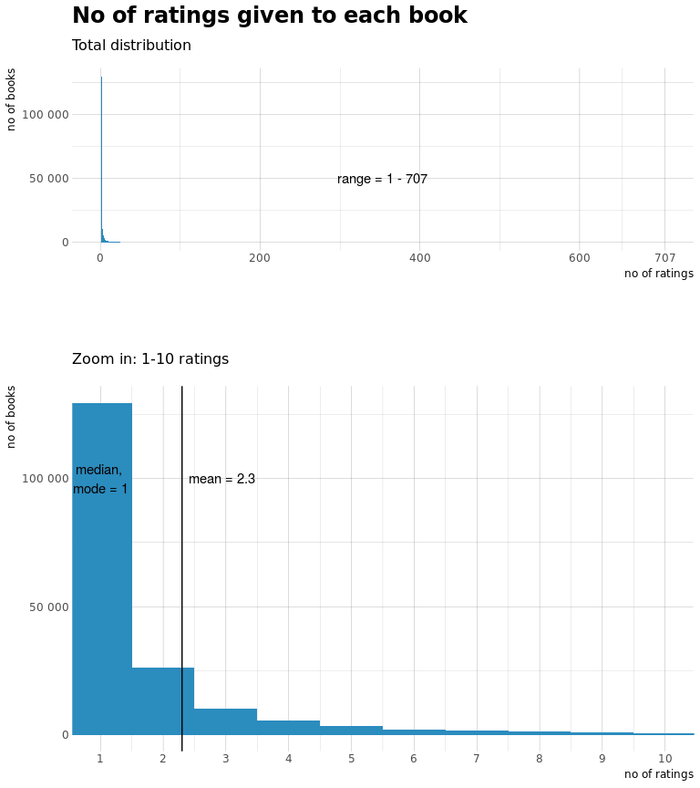

```r
# custom function to format axis labels
space <- function(x, ...) {
  format(x, ..., big.mark = " ", scientific = FALSE, trim = TRUE)
}

# no of raitings per book
book_count <- bx_book_ratings %>%
  filter(book_rating > 0) %>%
  count(isbn)

# Total distribution of all ratings
book_count_all <- book_count %>%
  ggplot(aes(n)) +
  geom_histogram(binwidth = 1, fill = "#2b8cbe") +
  theme_ipsum_rc() +
  scale_y_continuous(labels = space) +
  scale_x_continuous(breaks = c(seq(0, r_number_of_ratings_summary$max, by = 200),
                                r_number_of_ratings_summary$max),
                     limits = c(0, r_number_of_ratings_summary$max)) +
  geom_text(data = r_number_of_ratings_summary, aes(x = max / 2, y = 50000,
                                                    label = str_c("range = ", min, " - ", max))) +
  labs(title = "No of ratings given to each book",
       subtitle = "Total distribution",
       x = "no of ratings",
       y = "no of books")

# Zoom in: 1-10 ratings
book_count_zoom <- book_count %>%
  ggplot(aes(n)) +
  geom_histogram(binwidth = 1, fill = "#2b8cbe") +
  theme_ipsum_rc() +
  coord_cartesian(xlim = c(1, 10)) +
  scale_x_continuous(breaks = seq(1, 10, by = 1)) +
  scale_y_continuous(labels = space) +
  geom_vline(xintercept = r_number_of_ratings_summary$mean) +
  geom_text(data = r_number_of_ratings_summary, aes(x = mean, y = 100000,
                                                    label = str_c("mean = ", round(mean, 1))),
            hjust = -0.1) +
  geom_text(data = r_number_of_ratings_summary, aes(x = mode, y = 100000,
                                                    label = str_c("median, \nmode = ", round(mode, 1)))) +
  labs(subtitle = "Zoom in: 1-10 ratings",
       x = "no of ratings",
       y = "no of books")

# combine charts
book_count_all + book_count_zoom + plot_layout(ncol = 1, heights = c(1, 2))
```

## 3. Users and ratings - Pareto principle

If you look for users and ratings, does Pareto principle hold?

I will group user into quantiles based on the number of ratings they have given. Pareto principle applies when 20% of the top rating giving users account for ~80% of the all ratings.

### SQL query

There is no native NTILE function in SQLite. Therefor it requires heavier custom query writing. As of now, I will continue with calculations with R. In other SQL databases (MySQL, PostgreSQL etc) the query to calculate percentiles is something as follows:

```r
with user_id_rating as (
  select user_id,
  count(*) as n
  from bx_book_ratings
  where book_rating > 0
  group by user_id
)

select
ntile(5) over(order by n desc) as quantile
from user_id_rating
```

### R

```r
r_quantile_user_raitings <- bx_book_ratings %>%
  filter(book_rating != 0) %>%
  count(user_id) %>%
  mutate(quantile = ntile(desc(n), 5)) %>%
  group_by(quantile) %>%
  summarise(no_of_raitings = sum(n)) %>%
  ungroup() %>%
  mutate(percentage_of_raitings = no_of_raitings / sum(no_of_raitings),
         percentage_of_raitings_char = str_c(round(percentage_of_raitings, 3) * 100, "%"))
```

### Result

As the result show, Pareto principle applies to this dataset.

```r
r_quantile_user_raitings %>%
  select(-percentage_of_raitings) %>%
  kable("html") %>%
  kable_styling()
```

| quantile | no_of_raitings | percentage_of_raitings_char |
| --- | --- | --- |
| 1 | 345701 | 79.7% |
| 2 | 39980 | 9.2% |
| 3 | 16862 | 3.9% |
| 4 | 15560 | 3.6% |
| 5 | 15560 | 3.6% |

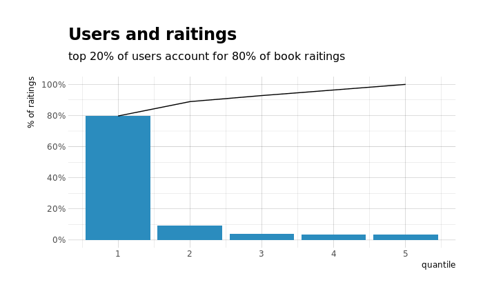

```r
r_quantile_user_raitings %>%
  mutate(cum_perc = cumsum(percentage_of_raitings)) %>%
  ggplot(aes(quantile, percentage_of_raitings)) +
  geom_col(fill = "#2b8cbe") +
  geom_line(aes(quantile, cum_perc)) +
  theme_ipsum_rc() +
  scale_y_continuous(labels = scales::percent,
                     breaks = seq(0, 1, by = 0.2)) +
  labs(title = "Users and raitings",
       subtitle = "top 20% of users account for 80% of book raitings",
       x = "quantile",
       y = "% of raitings")
```